# EE658/758 Machine Learning in Engineering

## Assignment 1: Linear Regression

#### Importing Libraries

```python
import os
import warnings

warnings.filterwarnings('ignore')

import pandas as pd
import numpy as np
import seaborn as sns
import matplotlib.pyplot as plt
from sklearn.model_selection import train_test_split
from sklearn.linear_model import LinearRegression
from sklearn.metrics import mean_squared_error, r2_score, mean_absolute_error
from sklearn.preprocessing import MinMaxScaler
from scipy.stats import zscore
from scipy.stats import norm
```

### 1. Data Preprocessing:

```python
data = pd.read_csv("insurance.csv")
```

```python
file_path = 'insurance.csv'

data = pd.read_csv(file_path)

sample_size = 10
data.head(sample_size)
```

|  | Age | Gender | BMI | Children | Smoker | Region | Expenses |
| --- | --- | --- | --- | --- | --- | --- | --- |
| 0 | 19 | female | 27.9 | 0 | yes | southwest | 16884.92 |
| 1 | 18 | male | 33.8 | 1 | no | southeast | 1725.55 |
| 2 | 28 | male | 33.0 | 3 | no | southeast | 4449.46 |
| 3 | 33 | male | 22.7 | 0 | no | northwest | 21984.47 |
| 4 | 32 | male | 28.9 | 0 | no | northwest | 3866.86 |
| 5 | 31 | female | 25.7 | 0 | no | southeast | 3756.62 |
| 6 | 46 | female | 33.4 | 1 | no | southeast | 8240.59 |
| 7 | 37 | female | 27.7 | 3 | no | northwest | 7281.51 |
| 8 | 37 | male | NaN | 2 | no | northeast | 6406.41 |
| 9 | 60 | female | 25.8 | 0 | no | northwest | 28923.14 |

```python
rows_with_missing_values = data[data.isnull().any(axis=1)]
num_rows_with_missing_values = len(rows_with_missing_values)

print(f"Number of rows with missing values: {num_rows_with_missing_values}")
```

```
Number of rows with missing values: 17
```

```python
def fill_missing_values(df, col_name):

    if col_name not in df.columns:
        print(f"Error: Column '{col_name}' not found in the DataFrame.")
        return

    if df[col_name].dtype == 'object':  # Categorical column
        mode_value = df[col_name].mode()[0]
        df[col_name].fillna(mode_value, inplace=True)
    else:  # Numeric column
        mean_value = df[col_name].mean()
        df[col_name].fillna(mean_value, inplace=True)

# Fill missing values in the specified column

for col in data.columns:
    fill_missing_values(data, col)

data.head()
```

|  | Age | Gender | BMI | Children | Smoker | Region | Expenses |
| --- | --- | --- | --- | --- | --- | --- | --- |
| 0 | 19 | female | 27.9 | 0 | yes | southwest | 16884.92 |
| 1 | 18 | male | 33.8 | 1 | no | southeast | 1725.55 |
| 2 | 28 | male | 33.0 | 3 | no | southeast | 4449.46 |
| 3 | 33 | male | 22.7 | 0 | no | northwest | 21984.47 |
| 4 | 32 | male | 28.9 | 0 | no | northwest | 3866.86 |

```python
def binary_encoding(df, column_name):

    if column_name not in df.columns:
        print(f"Error: Column '{column_name}' not found in the DataFrame.")
        return

    unique_values = df[column_name].unique()
    mapping = {value: i for i, value in enumerate(unique_values)}
    df[column_name] = df[column_name].map(mapping)

# Perform binary encoding using the function
binary_encoding(data, 'Gender')
binary_encoding(data, 'Smoker')
data.head()
```

|  | Age | Gender | BMI | Children | Smoker | Region | Expenses |
| --- | --- | --- | --- | --- | --- | --- | --- |
| 0 | 19 | 0 | 27.9 | 0 | 0 | southwest | 16884.92 |
| 1 | 18 | 1 | 33.8 | 1 | 1 | southeast | 1725.55 |
| 2 | 28 | 1 | 33.0 | 3 | 1 | southeast | 4449.46 |
| 3 | 33 | 1 | 22.7 | 0 | 1 | northwest | 21984.47 |
| 4 | 32 | 1 | 28.9 | 0 | 1 | northwest | 3866.86 |

```python
def one_hot_encoding(df, column_name):

    if column_name not in df.columns:
        print(f"Error: Column '{column_name}' not found in the DataFrame.")
        return

    # Perform one-hot encoding
    df = pd.get_dummies(df, columns=[column_name], prefix=column_name, drop_first=True)

    return df

# Perform one-hot encoding using the function
df = one_hot_encoding(data, 'Region')
df.head()
```

|  | Age | Gender | BMI | Children | Smoker | Expenses | Region_northwest | Region_southeast | Region_southwest |
| --- | --- | --- | --- | --- | --- | --- | --- | --- | --- |
| 0 | 19 | 0 | 27.9 | 0 | 0 | 16884.92 | 0 | 0 | 1 |
| 1 | 18 | 1 | 33.8 | 1 | 1 | 1725.55 | 0 | 1 | 0 |
| 2 | 28 | 1 | 33.0 | 3 | 1 | 4449.46 | 0 | 1 | 0 |
| 3 | 33 | 1 | 22.7 | 0 | 1 | 21984.47 | 1 | 0 | 0 |
| 4 | 32 | 1 | 28.9 | 0 | 1 | 3866.86 | 1 | 0 | 0 |

```python
def min_max_scaling(df, columns_to_normalize):
    scaler = MinMaxScaler()
    df[columns_to_normalize] = scaler.fit_transform(df[columns_to_normalize])

# Normalize features using Min-Max scaling
columns_to_normalize = ['Age', 'BMI', 'Children', 'Expenses']
min_max_scaling(df, columns_to_normalize)

df.head()
```

|  | Age | Gender | BMI | Children | Smoker | Expenses | Region_northwest | Region_southeast | Region_southwest |
| --- | --- | --- | --- | --- | --- | --- | --- | --- | --- |
| 0 | 0.021739 | 0 | 0.320755 | 0.481481 | 0 | 0.251611 | 0 | 0 | 1 |
| 1 | 0.000000 | 1 | 0.479784 | 0.488889 | 1 | 0.009636 | 0 | 1 | 0 |
| 2 | 0.217391 | 1 | 0.458221 | 0.503704 | 1 | 0.053115 | 0 | 1 | 0 |
| 3 | 0.326087 | 1 | 0.180593 | 0.481481 | 1 | 0.333010 | 1 | 0 | 0 |
| 4 | 0.304348 | 1 | 0.347709 | 0.481481 | 1 | 0.043816 | 1 | 0 | 0 |

### 2. Splitting the Data:

```python
# Divide the data into features (X) and target (y)
features = df.drop('Expenses', axis=1)  # Features are all columns except 'Expenses'
target = df['Expenses']  # Target is the 'Expenses' column

# Display the features and target
print("Features:")
print(features.head())

print("\nTarget:")
target.head()
```

```
Features:
        Age  Gender       BMI  Children  Smoker  Region_northwest  \
0  0.021739       0  0.320755  0.481481       0                 0
1  0.000000       1  0.479784  0.488889       1                 0
2  0.217391       1  0.458221  0.503704       1                 0
3  0.326087       1  0.180593  0.481481       1                 1
4  0.304348       1  0.347709  0.481481       1                 1

   Region_southeast  Region_southwest
0                 0                 1
1                 1                 0
2                 1                 0
3                 0                 0
4                 0                 0

Target:
```

```
0    0.251611
1    0.009636
2    0.053115
3    0.333010
4    0.043816
Name: Expenses, dtype: float64
```

```python
# Split the data into training and testing sets (80/20 split)
X_train, X_test, y_train, y_test = train_test_split(features, target, test_size=0.2, random_state=42)

# Display the shapes of the training and testing sets
print("Training set - Features shape:", X_train.shape)
print("Testing set - Features shape:", X_test.shape)
print("Training set - Target shape:", y_train.shape)
print("Testing set - Target shape:", y_test.shape)
```

```
Training set - Features shape: (1070, 8)
Testing set - Features shape: (268, 8)
Training set - Target shape: (1070,)
Testing set - Target shape: (268,)
```

### 3. Gradient Descent Implementation:

**Implement the gradient descent algorithm (without the Scikit-Learn library) to find the regression line. Initialize parameters randomly and update them iteratively to minimize the loss function. Record the loss value for each iteration:**

```python
N_train, D_train = X_train.shape
N_test, D_test = X_test.shape

# Ensure both training and test sets have the same number of features
D_train == D_test, "Number of features in training and test sets must match"

# Reshape bias to have the same number of rows as X
train_bias = np.ones((N_train, 1))
test_bias = np.ones((N_test, 1))

# Concatenate bias column to the training and test data
X_bias_train = np.concatenate((X_train, train_bias), axis=1)
X_bias_test = np.concatenate((X_test, test_bias), axis=1)

alpha = 0.01                  # Learning rate
n_iterations = 10000   # Number of iterations
w = np.random.randn(D_train+1)  # Weight matrix

costs = []                          # Loss value for each iteration
for iteration in range(n_iterations):
    # Calculate gradients
    gradients = 1/N_train * X_bias_train.T.dot(X_bias_train.dot(w) - y_train)

    # Update weights using gradients
    w = w - alpha * gradients

    # Calculate predictions and loss
    predictions = X_bias_train.dot(w)
    costs.append(mean_squared_error(y_train, predictions))

# Coefficients of the model
coefficients = w[:-1]
intercept = w[-1]
```

**Show the coefficients and intercept of the model.**

```python
# Print coefficients and intercept
print(f"Coefficients: {w[:-1]}")
print(f"Intercept: {w[-1]}")
```

```
Coefficients: [ 1.89580121e-01  3.28021909e-04  2.41963321e-01  8.70686718e-01
 -3.73640356e-01 -5.34381759e-03 -1.51626891e-02 -1.33695690e-02]
Intercept: -0.10981604414956632
```

**Modify the code to implement the exponential decay method for the learning rate.**

```python
# Get dimensions of the training and test data
N_train, D_train = X_train.shape
N_test, D_test = X_test.shape

# Ensure both training and test sets have the same number of features
D_train == D_test, "Number of features in training and test sets must match"

# Reshape bias to have the same number of rows as X
train_bias = np.ones((N_train, 1))
test_bias = np.ones((N_test, 1))

# Concatenate bias column to the training and test data
X_bias_train = np.concatenate((X_train, train_bias), axis=1)
X_bias_test = np.concatenate((X_test, test_bias), axis=1)

alpha = 0.01                  # Initial learning rate
n_iterations = 10000   # Number of iterations
decay_factor = 0.1   # Decay factor for learning rate
decay_interval = 10   # Decay learning rate after every 10 epochs

w_decay = np.random.randn(D_train+1)  # Weight matrix

costs_decay = []                          # Loss value for each iteration
for iteration in range(n_iterations):
    # Calculate gradients
    gradients = 1/N_train * X_bias_train.T.dot(X_bias_train.dot(w_decay) - y_train)

    # Update weights using gradients
    w_decay = w_decay - alpha * gradients

    # Calculate predictions and loss
    predictions = X_bias_train.dot(w_decay)
    costs_decay.append(mean_squared_error(y_train, predictions))

    # Decay learning rate after every decay_interval epochs
    if iteration % decay_interval == 0:
        alpha *= decay_factor

# Coefficients of the model
coefficients = w_decay[:-1]
intercept = w_decay[-1]

print("Coefficients:", coefficients)
print("Intercept:", intercept)
```

```
Coefficients: [-0.74688005 -0.37218998 -1.14632733  0.20706036  0.02855772  0.44061682
 -2.25679494  0.04657118]
Intercept: -0.30549101431913356
```

**Plot the loss values as a function of the number of iterations for the constant and decaying learning rates.**

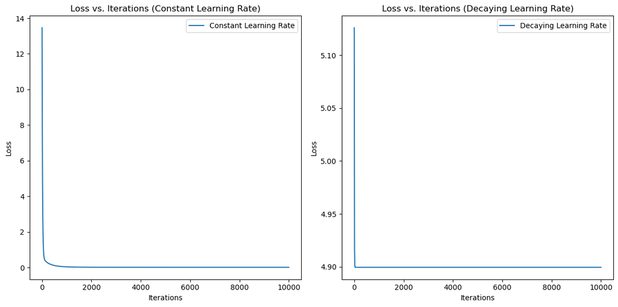

```python
fig, axs = plt.subplots(1, 2, figsize=(12, 6))

# Plot the loss values for constant learning rate
axs[0].plot(costs, label='Constant Learning Rate')
axs[0].set_xlabel('Iterations')
axs[0].set_ylabel('Loss')
axs[0].set_title('Loss vs. Iterations (Constant Learning Rate)')
axs[0].legend()

# Plot the loss values for decaying learning rate
axs[1].plot(costs_decay, label='Decaying Learning Rate')
axs[1].set_xlabel('Iterations')
axs[1].set_ylabel('Loss')
axs[1].set_title('Loss vs. Iterations (Decaying Learning Rate)')
axs[1].legend()

# Adjust layout to prevent overlap
plt.tight_layout()

# Show the plots
plt.show()
```

### 4. Predict the expenses for the testing dataset using the trained model.

**Compute the Mean Absolute Error (MAE) and Mean Squared Error (MSE) of the predictions.**

```python
bias = np.ones((X_test.shape[0], 1))  # Reshape bias to have the same number of rows as X
X_test_bias = np.concatenate((X_test, bias), axis=1)
y_pred_const = X_test_bias.dot(w)
print("The MAE and MSE for gradient descent algorithm:(constant learning rate)")

print(f"Mean Absolute Error: {mean_absolute_error(y_test, y_pred_const)}")

print(f"Mean Squared Error: {mean_squared_error(y_test, y_pred_const)}")
print()

y_pred_decay = X_test_bias.dot(w_decay)
print("The MAE and MSE for exponential decaying learning rate:")

print(f"Mean Absolute Error: {mean_absolute_error(y_test, y_pred_decay)}")

print(f"Mean Squared Error: {mean_squared_error(y_test, y_pred_decay)}")
```

```
The MAE and MSE for gradient descent algorithm:(constant learning rate)
Mean Absolute Error: 0.06889166383272323
Mean Squared Error: 0.00861864317382681

The MAE and MSE for exponential decaying learning rate:
Mean Absolute Error: 1.9167715678251571
Mean Squared Error: 5.4642037684939835
```

[figure not shown]

```python
fig, axs = plt.subplots(1, 2, figsize=(12, 6))

# Plot the loss values for constant learning rate
axs[0].hist(costs, label='Constant Learning Rate')
axs[0].set_xlabel('Iterations')
axs[0].set_ylabel('Loss')
axs[0].set_title('Loss vs. Iterations (Constant Learning Rate)')
axs[0].legend()

# Plot the loss values for decaying learning rate
axs[1].hist(costs_decay, label='Decaying Learning Rate')
axs[1].set_xlabel('Iterations')
axs[1].set_ylabel('Loss')
axs[1].set_title('Loss vs. Iterations (Decaying Learning Rate)')
axs[1].legend()

# Adjust layout to prevent overlap
plt.tight_layout()

# Show the plots
plt.show()
```

### 5. Learning Rate Analysis:

**Demonstrate the effect of varying the learning rate on the convergence of the gradient descent algorithm**

[figure not shown]

```python
# Function to train the LinearRegression model with different learning rates and plot the loss curve
def train_and_plot_learning_rate_effect(X_train, y_train, learning_rates):
    plt.figure(figsize=(10, 6))
    for initial_learning_rate in learning_rates:
        # Initialize weights randomly
        alpha = 0.01                  # Initial learning rate
        n_iterations = 10000   # Number of iterations
        decay_factor = 0.1   # Decay factor for learning rate
        decay_interval = 10   # Decay learning rate after every 10 epochs

        w_decay = np.random.randn(D_train+1)  # Weight matrix

        costs_decay = []                          # Loss value for each iteration
        for iteration in range(n_iterations):
            # Calculate gradients
            gradients = 1/N_train * X_bias_train.T.dot(X_bias_train.dot(w_decay) - y_train)

            # Update weights using gradients
            w_decay = w_decay - alpha * gradients

            # Calculate predictions and loss
            predictions = X_bias_train.dot(w_decay)
            costs_decay.append(mean_squared_error(y_train, predictions))

            # Decay learning rate after every decay_interval epochs
            if iteration % decay_interval == 0:
                alpha *= decay_factor

        # Plot the loss curve for the current learning rate
        iterations = np.arange(len(costs_decay))
        plt.plot(iterations, costs_decay, label=f'Learning Rate: {initial_learning_rate}')

    plt.xlabel('Iterations')
    plt.ylabel('Loss')
    plt.title('Effect of Learning Rate on Convergence')
    plt.legend()
    plt.show()

# Define a range of learning rates to test
learning_rates = [0.001, 0.01, 0.1, 0.5, 1.0]

# Call the function to train and plot the effect of different learning rates
train_and_plot_learning_rate_effect(X_train, y_train, learning_rates)
```

### 6. Scikit-learn Implementation:

**Repeat the regression using the linear_model.LinearRegression class from scikit-learn.**

**Compute MAE and MSE for comparison.**

```python
regressor  = LinearRegression()

regressor.fit(X_train, y_train)

y_pred = regressor.predict(X_test)

print(f"Mean Absolute Error: {mean_absolute_error(y_test, y_pred)}")

print(f"Mean Squared Error: {mean_squared_error(y_test, y_pred)}")
```

```
Mean Absolute Error: 0.0672095923578727
Mean Squared Error: 0.008663799169026478
```

### 7. Normal Equation Implementation:

**Use the normal equation method to find the regression line directly.**

```python
w = np.linalg.solve(np.dot(X_bias_train.T, X_bias_train), np.dot(X_bias_train.T, y_train))
Yhat = np.dot(X_bias_train, w)


# determine how good the model is by computing the r-squared
error = y_train - Yhat
avg_error = y_train - y_train.mean()
r_squared = 1 - error.dot(error) / avg_error.dot(avg_error)
print("The Mean Squared Error for train data is:", r_squared)
```

[output not shown]

```python
w = np.linalg.solve(np.dot(X_bias_test.T, X_bias_test), np.dot(X_bias_test.T, y_test))
Yhat = np.dot(X_bias_test, w)


# determine how good the model is by computing the r-squared
error = y_test - Yhat
avg_error = y_test - y_test.mean()
r_squared = 1 - error.dot(error) / avg_error.dot(avg_error)
print("The Mean Squared Error for test data is:", r_squared)
```

[output not shown]

**Compare the MAE and MSE with previous methods.**

**2. The values of MAE and MSE obtained by Scikit-learn Implementation are:**

Mean Absolute Error: 0.0672095923578727

Mean Squared Error: 0.008663799169026478

**3. Values of MAE and MSE obtained by Predicting the expenses for the testing dataset using the trained model are:**

### 8. Comparison

**Compare the three solutions in terms of MAE, MSE, and computational efficiency.**

**Gradient Descent with Constant Learning Rate:**

Computational Efficiency: Medium

- It requires iterating over a fixed number of iterations (10,000 in this case), which might be computationally expensive for large datasets. However, it has the advantage of being able to handle large datasets efficiently due to its iterative nature.

**Gradient Descent with Exponential Decaying Learning Rate:**

Computational Efficiency: Similar to the constant learning rate gradient descent

- It also requires iterating over a fixed number of iterations (10,000) but with the addition of a decaying learning rate, which might help converge faster compared to a constant learning rate. However, in this particular implementation, it seems that the learning rate decay might be too aggressive, leading to worse performance.

**Scikit-learn Linear Regression:**

MAE: 0.0672

MSE: 0.00866

Computational Efficiency: High

- Scikit-learn's Linear Regression implementation typically utilizes optimized numerical libraries (like BLAS/LAPACK) under the hood, making it computationally efficient. It also provides good performance out-of-the-box without requiring manual tuning of learning rates or other hyperparameters.

**Normal Equation:**

Computational Efficiency: Medium

- The normal equation provides a closed-form solution to linear regression, which can be computationally expensive for large datasets due to matrix inversions. However, for small to medium-sized datasets, it can be efficient and provides accurate results without the need for iterative optimization.

Theoretical Considerations:

- Scikit-learn: Leverages optimized implementations, handles different loss functions.
- Gradient Descent: Flexible, requires setting learning rate and number of iterations.
- Normal Equation: Provides closed-form solution, sensitive to data size and condition number.

Overall:

- Scikit-learn: Practical choice for good accuracy and efficiency across varied datasets.
- Gradient Descent: Offers flexibility and potential for optimization, but requires tuning and understanding.
- Normal Equation: Mainly considered for smaller datasets or theoretical understanding, as its efficiency scales poorly.